# EDA

### Check for the structure of the dataset

```r
glimpse(train)
```

```
## Observations: 17,277
## Variables: 21
## $ id            <dbl> 9183703376, 464000600, 2224079050, 6163901283, 6...
## $ date          <fct> 5/13/2014, 8/27/2014, 7/18/2014, 1/30/2015, 5/23...
## $ price         <dbl> 225000, 641250, 810000, 330000, 530000, 953007, ...
## $ bedrooms      <int> 3, 3, 4, 4, 4, 4, 4, 3, 4, 3, 4, 3, 5, 3, 3, 2, ...
## $ bathrooms     <dbl> 1.50, 2.50, 3.50, 1.50, 1.75, 3.50, 3.25, 2.25, ...
## $ sqft_living   <int> 1250, 2220, 3980, 1890, 1814, 3120, 4160, 1440, ...
## $ sqft_lot      <int> 7500, 2550, 209523, 7540, 5000, 5086, 47480, 105...
## $ floors        <dbl> 1.0, 3.0, 2.0, 1.0, 1.0, 2.0, 2.0, 1.0, 2.0, 1.0...
## $ waterfront    <int> 0, 0, 0, 0, 0, 0, 0, 0, 0, 0, 0, 0, 0, 0, 0, 0, ...
## $ view          <int> 0, 2, 2, 0, 0, 0, 0, 0, 0, 0, 0, 0, 0, 0, 1, 0, ...
## $ condition     <int> 3, 3, 3, 4, 4, 3, 3, 3, 3, 3, 3, 3, 4, 4, 3, 3, ...
## $ grade         <int> 7, 10, 9, 7, 7, 9, 10, 8, 9, 8, 7, 7, 7, 9, 8, 7...
## $ sqft_above    <int> 1250, 2220, 3980, 1890, 944, 2480, 4160, 1130, 2...
## $ sqft_basement <int> 0, 0, 0, 0, 870, 640, 0, 310, 0, 1040, 0, 0, 130...
## $ yr_built      <int> 1967, 1990, 2006, 1967, 1951, 2008, 1995, 1983, ...
## $ yr_renovated  <int> 0, 0, 0, 0, 0, 0, 0, 0, 0, 0, 0, 0, 0, 0, 2010, ...
## $ zipcode       <int> 98030, 98117, 98024, 98155, 98115, 98115, 98072,...
## $ lat           <dbl> 47.3719, 47.6963, 47.5574, 47.7534, 47.6840, 47....
## $ long          <dbl> -122.215, -122.393, -121.890, -122.318, -122.281...
## $ sqft_living15 <int> 1260, 2200, 2220, 1890, 1290, 1880, 3400, 1510, ...
## $ sqft_lot15    <int> 7563, 5610, 65775, 8515, 5000, 5092, 40428, 8125...
```

```r
head(train)
```

|  | id | date | price | bedrooms | bathrooms | sqft_living | sqft_lot | floors | waterfront | view | condition | grade | sqft_above | sqft_basement | yr_built | yr_renovated | zipcode | lat | long | sqft_living15 | sqft_lot15 |
| --- | --- | --- | --- | --- | --- | --- | --- | --- | --- | --- | --- | --- | --- | --- | --- | --- | --- | --- | --- | --- | --- |
| 1 | 9183703376 | 5/13/2014 | 225000 | 3 | 1.50 | 1250 | 7500 | 1 | 0 | 0 | 3 | 7 | 1250 | 0 | 1967 | 0 | 98030 | 47.3719 | -122.215 | 1260 | 7563 |
| 2 | 464000600 | 8/27/2014 | 641250 | 3 | 2.50 | 2220 | 2550 | 3 | 0 | 2 | 3 | 10 | 2220 | 0 | 1990 | 0 | 98117 | 47.6963 | -122.393 | 2200 | 5610 |
| 3 | 2224079050 | 7/18/2014 | 810000 | 4 | 3.50 | 3980 | 209523 | 2 | 0 | 2 | 3 | 9 | 3980 | 0 | 2006 | 0 | 98024 | 47.5574 | -121.890 | 2220 | 65775 |
| 4 | 6163901283 | 1/30/2015 | 330000 | 4 | 1.50 | 1890 | 7540 | 1 | 0 | 0 | 4 | 7 | 1890 | 0 | 1967 | 0 | 98155 | 47.7534 | -122.318 | 1890 | 8515 |
| 5 | 6392003810 | 5/23/2014 | 530000 | 4 | 1.75 | 1814 | 5000 | 1 | 0 | 0 | 4 | 7 | 944 | 870 | 1951 | 0 | 98115 | 47.6840 | -122.281 | 1290 | 5000 |
| 6 | 7974200948 | 5/20/2014 | 953007 | 4 | 3.50 | 3120 | 5086 | 2 | 0 | 0 | 3 | 9 | 2480 | 640 | 2008 | 0 | 98115 | 47.6762 | -122.288 | 1880 | 5092 |

### Check if there are any missing values in training and test datasets

```
## [1] "Train NAs:"
```

```
## [1] 0
```

```
## [1] "Test NAs:"
```

```
## [1] 0
```

**No NAs found**

#### Histograms of numerical Features

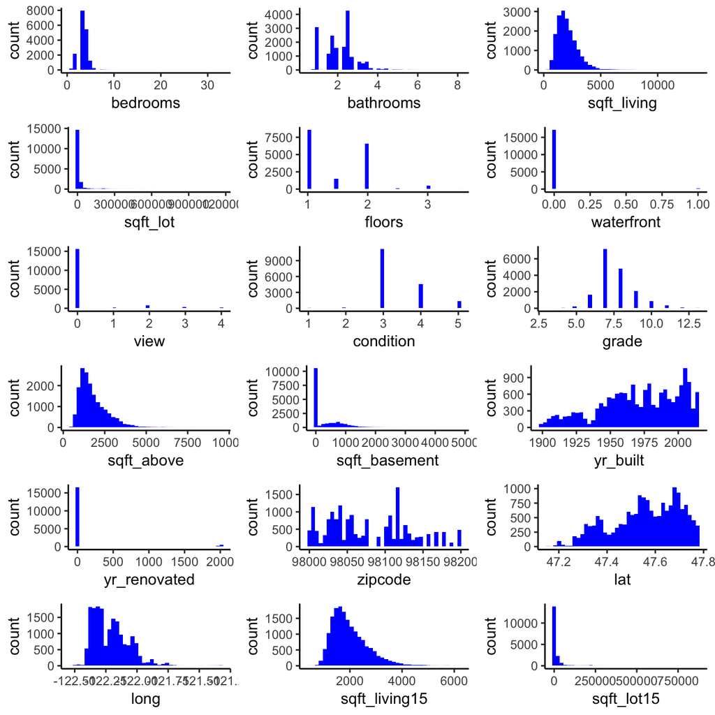

**Some skewed distributions**

**Skewed vairables can be a problem for linear regression**

#### Histograms against target

**Color coded by Price Quantile 1=lowest 25%, 4= highest 25%**

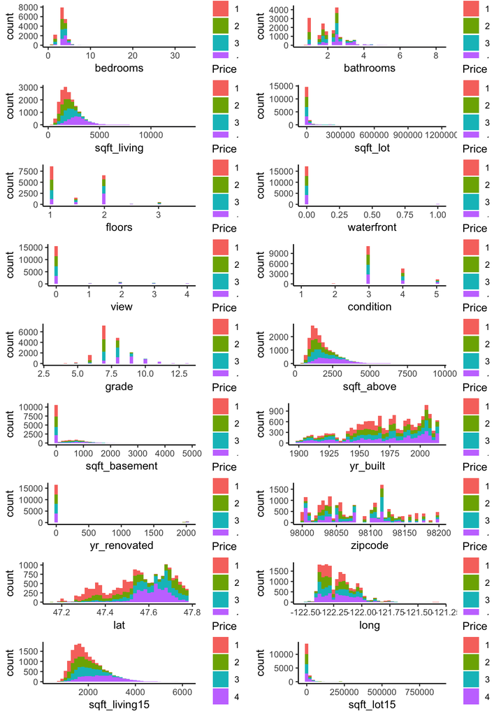

**Pay attention to it in variable correlation analysis!!**

#### Variable skewness sorted

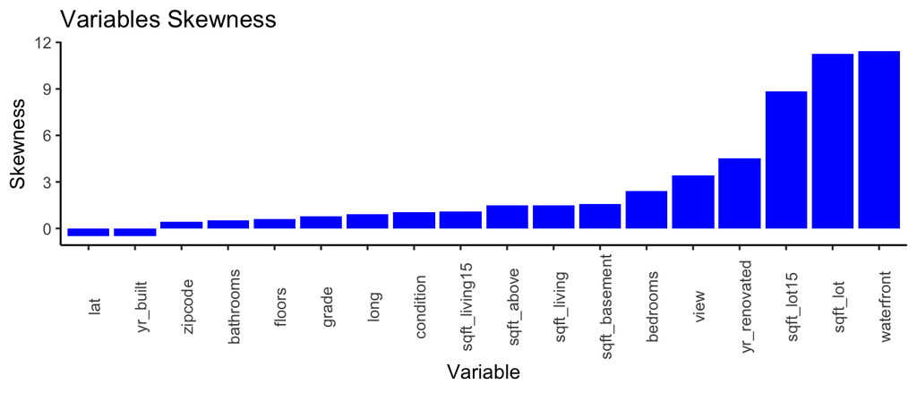

#### Distribution of Target variable

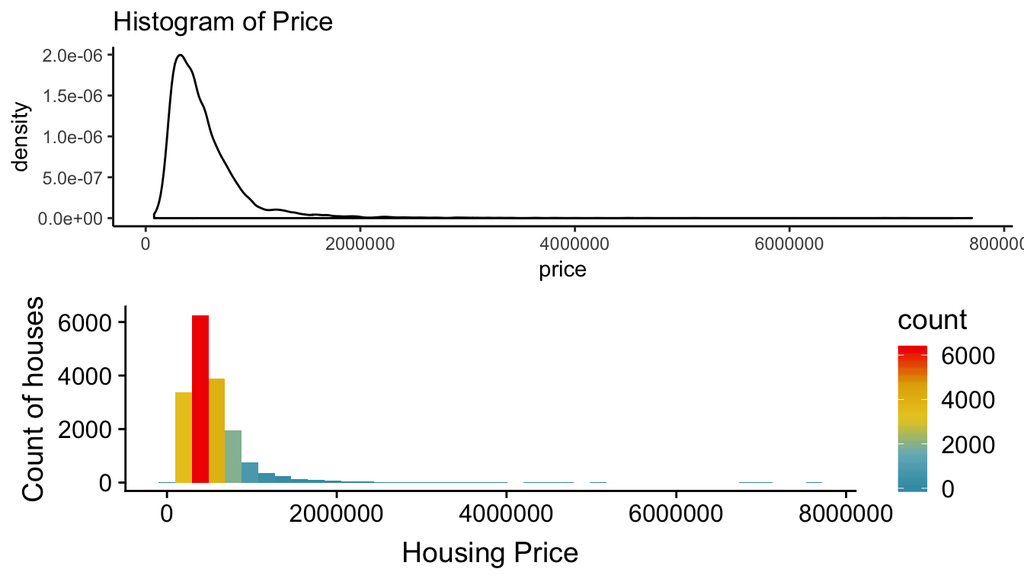

```
##    Min. 1st Qu.  Median    Mean 3rd Qu.    Max.
##   78000  320000  450000  539865  645500 7700000
```

**From these shapes, the distribution of our target variable `price` is skewed to right.**

**One appriach to fix this skewness is taking the log of price.**

#### Try taking log of price

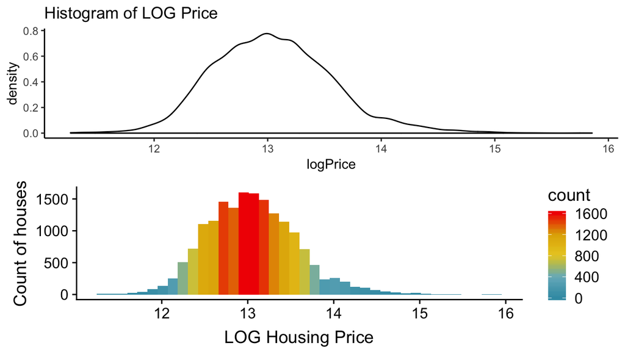

```
##    Min. 1st Qu.  Median    Mean 3rd Qu.    Max.
##   11.26   12.68   13.02   13.05   13.38   15.86
```

**logPrice is now normally distributed. We can use this with linear models**

TODO in FE: log Target Variable (Price)

#### Check date varibale format

```r
head(train$date)
```

```
## [1] 5/13/2014 8/27/2014 7/18/2014 1/30/2015 5/23/2014 5/20/2014
## 372 Levels: 1/10/2015 1/12/2015 1/13/2015 1/14/2015 1/15/2015 ... 9/9/2014
```

**It’s better to convert it to just number so we can check corrleation with target**

#### Correlation between two numerical features

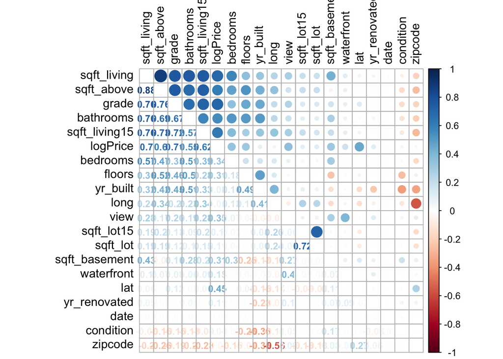

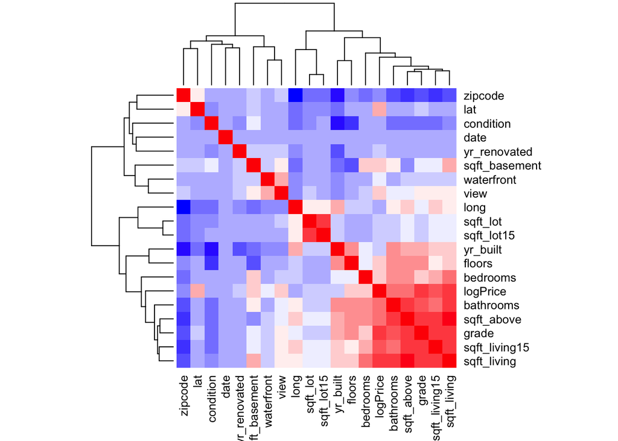

**There is a high correlation between some of the variables, this can be a problem with linear regression**

# Correlations with Target variable

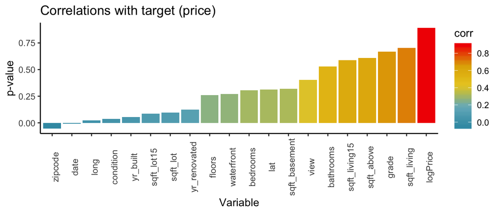

|  | corr | var |
| --- | --- | --- |
| date | -0.007349106 | date |
| bedrooms | 0.305543839 | bedrooms |
| bathrooms | 0.527557762 | bathrooms |
| sqft_living | 0.703537126 | sqft_living |
| sqft_lot | 0.094726455 | sqft_lot |
| floors | 0.258880751 | floors |
| waterfront | 0.270429537 | waterfront |
| view | 0.402948759 | view |
| condition | 0.035890808 | condition |
| grade | 0.670026774 | grade |

[output cut: 10 more lines]

Very weakly correlated variables:

- sqft_lot, sqft_lot15, date, yr_built, long

Needs more analysis:

- condition, waterfront, bathrooms, and floors may be considered as categorical vars so leave them for now.

TODO in FE: Drop sqft_lot, sqft_lot15, date, yr_built, long

#### Zeroing in on Multicollinearity (most correlated varibales with each other)

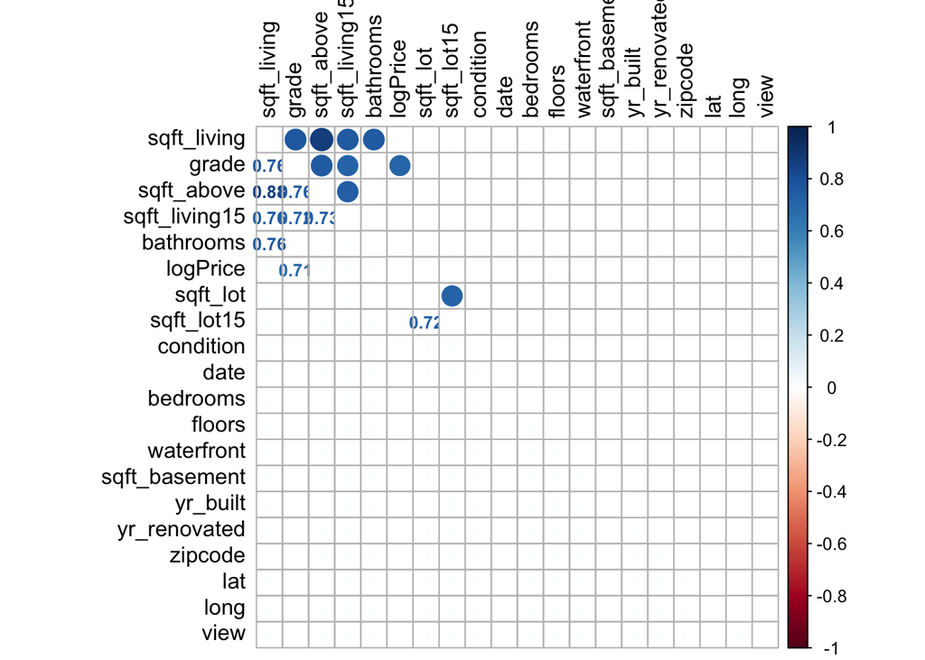

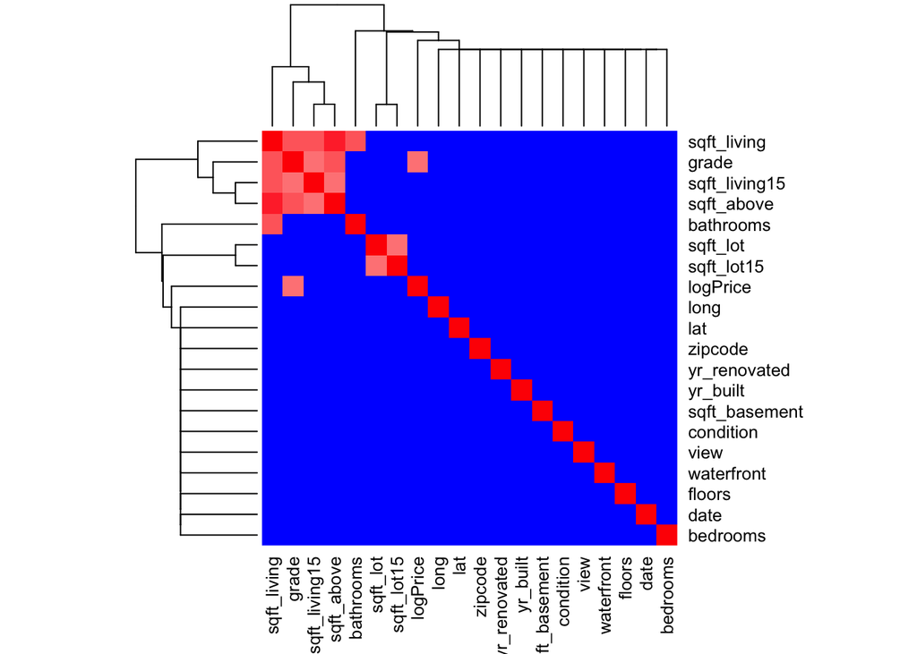

Highly correlated variables with each other:

- sqft_living and sqft_above have a correlation of 0.88
- sqft_above and grade have a correlation of 0.76 (ignore as sqft_above will be drop anyway)
- sqft_living and sqft_living15 have a correlation of 0.76
- sqft_living and grade have a correlation of 0.76
- sqft living and bathrooms have a correlation of 0.76
- sqft_lot and sqft_lot15 have a correlation of 0.72 (ignore as both will be drop anyway)

#### Check Multicollinearity between sqft_living and sqft_above have (0.88) using VIF

**http://www.sthda.com/english/articles/39-regression-model-diagnostics/160-multicollinearity-essentials-and-vif-in-r/**

```r
model = lm(formula = price ~ sqft_living + sqft_above,
               data = train)
vif(model)
```

```
## sqft_living  sqft_above
##      4.3617      4.3617
```

**Very close to 5 (upper limit according to articles)**

**However sqft_living had the higheist collinearity with price.**

TODO in FE: Drop sqft_above

#### Check Multicollinearity between sqft_living and sqft_living15 have (0.76) using VIF

```r
model = lm(formula = price ~ sqft_living + sqft_living15,
               data = train)
vif(model)
```

```
##   sqft_living sqft_living15
##        2.3295        2.3295
```

**Below 5, keep both**

#### Check Multicollinearity between sqft_living and grade have (0.76) using VIF

```r
model = lm(formula = price ~ sqft_living + grade,
               data = train)
vif(model)
```

```
## sqft_living       grade
##      2.3953      2.3953
```

**Below 5, keep both**

#### Check Multicollinearity between sqft_living and bathrooms have (0.76) using VIF

```r
model = lm(formula = price ~ sqft_living + bathrooms,
               data = train)
vif(model)
```

```
## sqft_living   bathrooms
##      2.3314      2.3314
```

**Below 5, keep both**

#### Potential factor variables

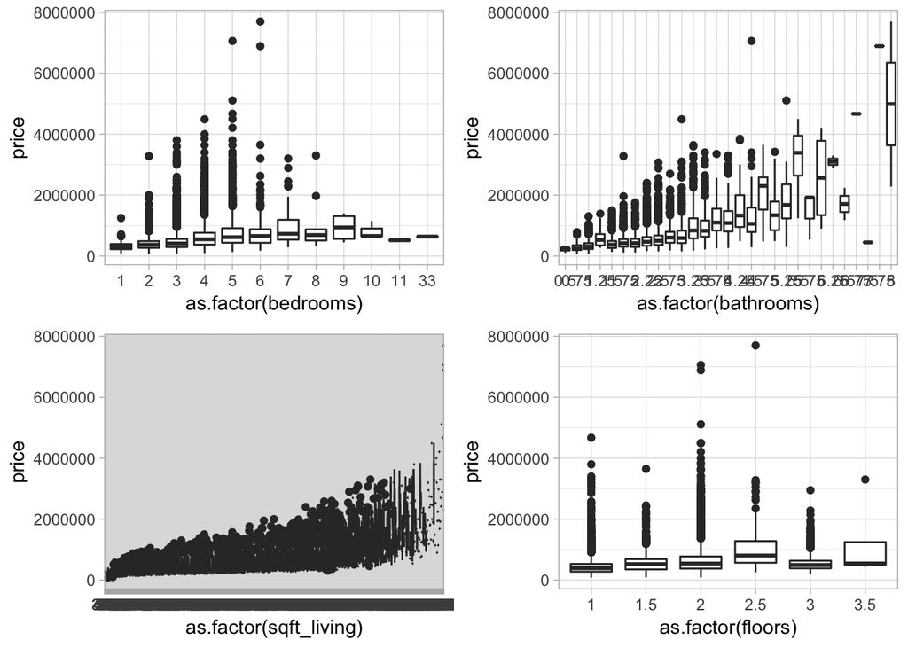

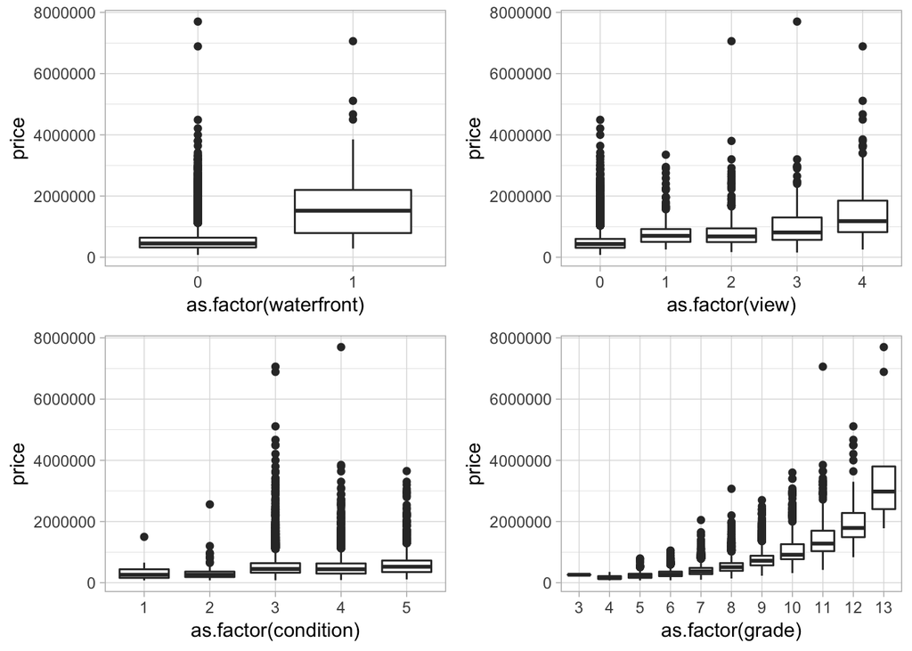

TODO in FE: Convert bedrooms, floors, waterfronts, view, and condition to factor

TODO in FE: Remove rows for bedroooms = 11 or 33